# Daily Step Analysis

## Synopsis

This project is for Cousera Reproducible Research Course Projet 1. The aim is to fulfil the required assignment instructions as below:

*Assignment Instructions:*

1. Code for reading in the dataset and/or processing the data
2. Histogram of the total number of steps taken each day
3. Mean and median number of steps taken each day
4. Time series plot of the average number of steps taken
5. The 5-minute interval that, on average, contains the maximum number of steps
6. Code to describe and show a strategy for imputing missing data
7. Histogram of the total number of steps taken each day after missing values are imputed
8. Panel plot comparing the average number of steps taken per 5-minute interval across weekdays and weekends
9. All of the R code needed to reproduce the results (numbers, plots, etc.) in the report

### Steps in the project

- Load Data
- Convert date format from character to date
- Realize item 2 to 8 required in assignment. The item 9 is covered in all of them.

## Loading Data

```r
#download original data for first time

#url <- "https://d396qusza40orc.cloudfront.net/repdata%2Fdata%2Factivity.zip"
#origfile <- tempfile()
#download.file(url, origfile)
#unzip(origfile)
#unlink(origfile)

activity <- read.csv("activity.csv", sep=",")

dim(activity)
```

```
## [1] 17568     3
```

```r
head(activity)
```

```
##   steps       date interval
## 1    NA 2012-10-01        0
## 2    NA 2012-10-01        5
## 3    NA 2012-10-01       10
## 4    NA 2012-10-01       15
## 5    NA 2012-10-01       20
## 6    NA 2012-10-01       25
```

The source data set is stored locally after downloading, so it is directly read from loal file.

Three variables are inlcuded in the downloaded date: - steps: Number of steps taking in 5 minutes interval. Some are missing with value 'NA'. - date: Day of the record. They need be converted to Date format. - interval: The time interval identifier for that day.

Following libraries are required:

```r
library(ggplot2)
library(dplyr)
library(gridExtra)
Sys.setlocale("LC_TIME", "English")
```

```
## [1] "English_United States.1252"
```

## Clean Data

### Update date format

The variable date format is converted from character to "Date".

```r
class(activity$date)
```

```
## [1] "character"
```

```r
activity$date <- as.Date(activity$date, format = "%Y-%m-%d")
class(activity$date)
```

```
## [1] "Date"
```

## Item 2: Histogram of total number of steps taken each day

## Item 3: Mean and median of total number of steps taken each day

```r
stepsPerDay <- aggregate(steps ~ date, data = activity, sum, na.action = na.omit)

meanStepsbyDay <- mean(stepsPerDay$steps, na.rm=TRUE)
print(meanStepsbyDay)
```

```
## [1] 10766.19
```

```r
medianStepsbyDay <- median(stepsPerDay$steps, na.rm=TRUE)
print(medianStepsbyDay)
```

```
## [1] 10765
```

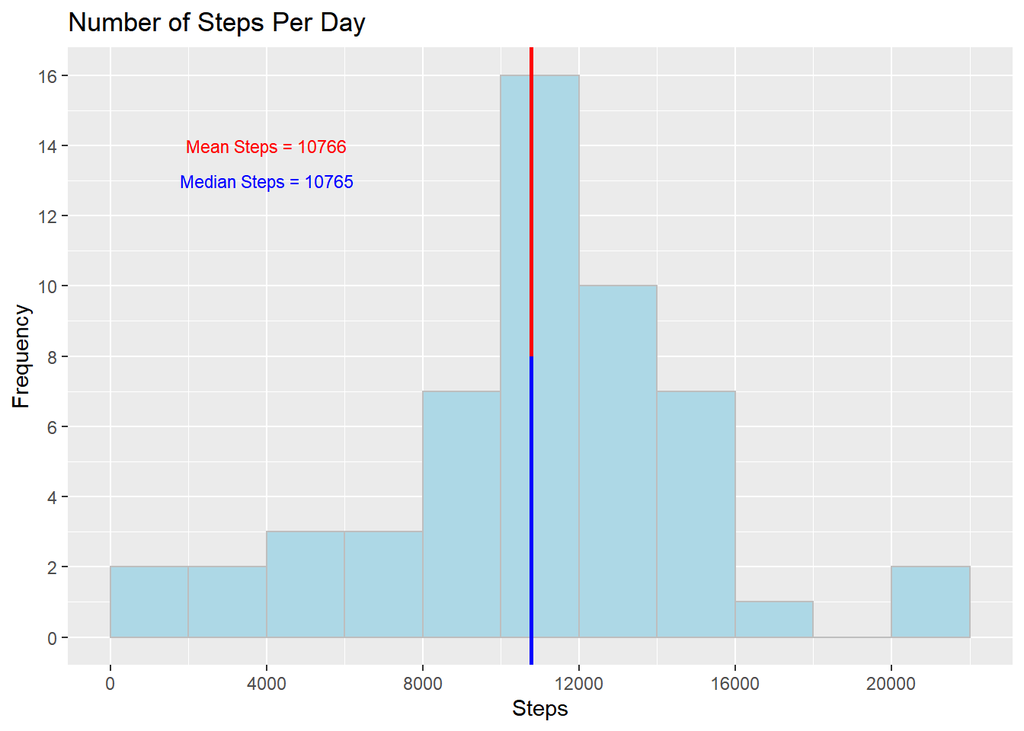

```r
g <- ggplot(stepsPerDay, aes(steps))
g + geom_histogram(boundary = 0, binwidth = 2000, col = "grey", fill="lightblue") +
  ggtitle("Number of Steps Per Day") +
  xlab("Steps") + ylab("Frequency") +
  scale_x_continuous(breaks=seq(0,24000,4000)) +
  scale_y_continuous(breaks=seq(0,20,2)) +
  geom_segment(size=1, colour="red", aes(x=meanStepsbyDay, y=8, xend=meanStepsbyDay, yend=Inf)) +
  geom_segment(size=1, colour="blue", aes(x=medianStepsbyDay, y=8, xend=medianStepsbyDay, yend=-Inf)) +
  annotate("text", x=4000, y=14, label=paste("Mean Steps =", as.character(round(meanStepsbyDay))), color="red", size = 3) +
  annotate("text", x=4000, y=13, label=paste("Median Steps =", as.character(round(medianStepsbyDay))), color="blue", size = 3)
```

```r
#save figure
dev.copy(png, file = "DailySteps_2&3.png", height = 600, width = 600)
```

```r
dev.off()
```

## Item4: Time series plot of the average number of steps taken

## The 5-minute interval that, on average, contains the maximum number of steps

```r
avgStepsPerTime <- aggregate(steps ~ interval, data = activity, mean, na.action = na.omit)

maxStepsPerTime <- subset(avgStepsPerTime, steps==max(avgStepsPerTime$steps))
print(maxStepsPerTime)
```

```
##     interval    steps
## 104      835 206.1698
```

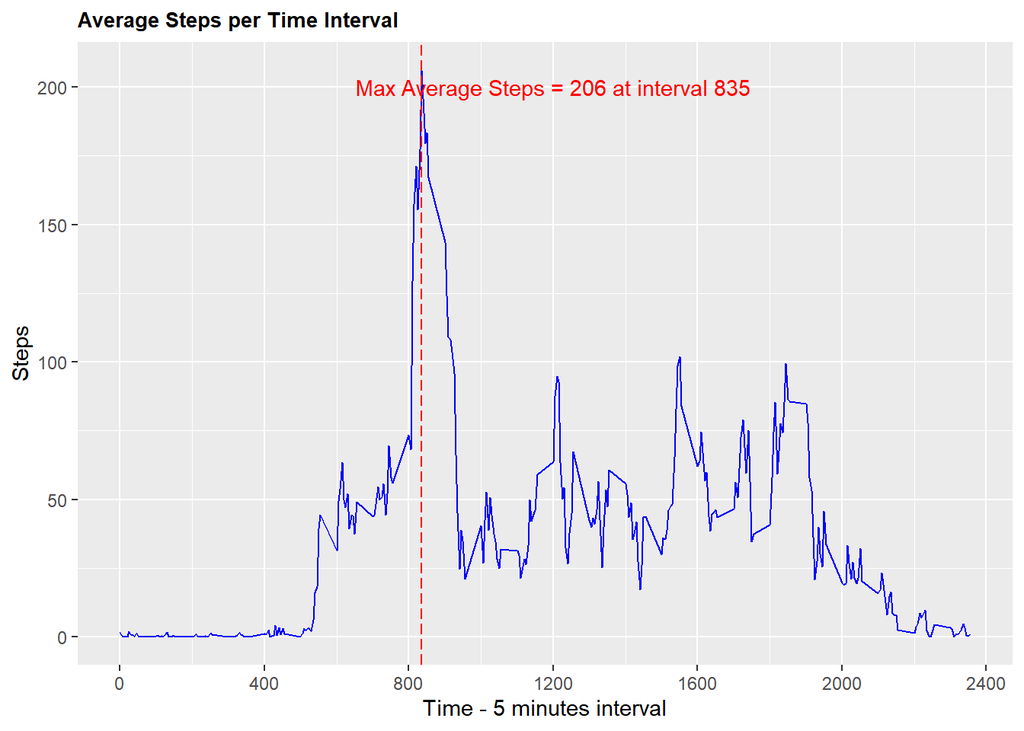

```r
g <- ggplot(avgStepsPerTime, aes(interval, steps))
g + geom_line(col = "blue") +
  ggtitle("Average Steps per Time Interval") +
  xlab("Time - 5 minutes interval") + ylab("Steps") +
  scale_x_continuous(breaks=seq(0,2400,400)) +
  scale_y_continuous(breaks=seq(0,250,50)) +
  theme(plot.title = element_text(face="bold", size=10)) +
  geom_vline(xintercept=maxStepsPerTime$interval, colour="red", linetype="longdash") +
  annotate("text", x=1200, y=200, label=paste("Max Average Steps =", as.character(round(maxStepsPerTime$steps)), "at interval", as.character(maxStepsPerTime$interval)), color="red")
```

```r
#save figure
dev.copy(png, file = "DailySteps_4&5.png", height = 600, width = 600)
```

```r
dev.off()
```

## Item6: Imputing missing data by average steps for that interval

```r
#Records with NA steps
length(which(is.na(activity$steps)))
```

```
## [1] 2304
```

```r
head(activity)
```

```
##   steps       date interval
## 1    NA 2012-10-01        0
## 2    NA 2012-10-01        5
## 3    NA 2012-10-01       10
## 4    NA 2012-10-01       15
## 5    NA 2012-10-01       20
## 6    NA 2012-10-01       25
```

```r
#Impute the steps as NA with average steps of that interval
activityFull <- activity

activityFull$steps[which(is.na(activityFull$steps))] <-
    ceiling(avgStepsPerTime$steps[match(activityFull$interval, avgStepsPerTime$interval)])
length(which(is.na(activityFull$steps)))
```

```
## [1] 0
```

```r
head(activityFull)
```

```
##   steps       date interval
## 1     2 2012-10-01        0
## 2     1 2012-10-01        5
## 3     1 2012-10-01       10
## 4     1 2012-10-01       15
## 5     1 2012-10-01       20
## 6     3 2012-10-01       25
```

## Item7: Histogram of the total number of steps taken each day after missing values are imputed

```r
# figure of raw data set
g <- ggplot(stepsPerDay, aes(steps)) +
  geom_histogram(boundary = 0, binwidth = 2000, col = "grey", fill="lightblue") +
  ggtitle("Number of Steps Per Day - Raw Data") +
  xlab("Steps") + ylab("Frequency") +
  scale_x_continuous(breaks=seq(0,24000,4000)) +
  scale_y_continuous(breaks=seq(0,20,2)) +
  geom_segment(size=1, colour="red", aes(x=meanStepsbyDay, y=8, xend=meanStepsbyDay, yend=Inf)) +
  geom_segment(size=1, colour="blue", aes(x=medianStepsbyDay, y=8, xend=medianStepsbyDay, yend=0)) +
  annotate("text", x=5000, y=14, label=paste("Mean Steps =", as.character(round(meanStepsbyDay))), color="red", size = 3) +
  annotate("text", x=5000, y=12, label=paste("Median Steps =", as.character(round(medianStepsbyDay))), color="blue", size = 3)

# Calculate for new data by imputing NA steps
stepsPerDayFull <- aggregate(steps ~ date, data = activityFull, sum, na.action = na.omit)

meanStepsbyDayFull <- mean(stepsPerDayFull$steps, na.rm=TRUE)
print(meanStepsbyDayFull)
```

```
## [1] 10784.92
```

```r
medianStepsbyDayFull <- median(stepsPerDayFull$steps, na.rm=TRUE)
print(medianStepsbyDayFull)
```

```
## [1] 10909
```

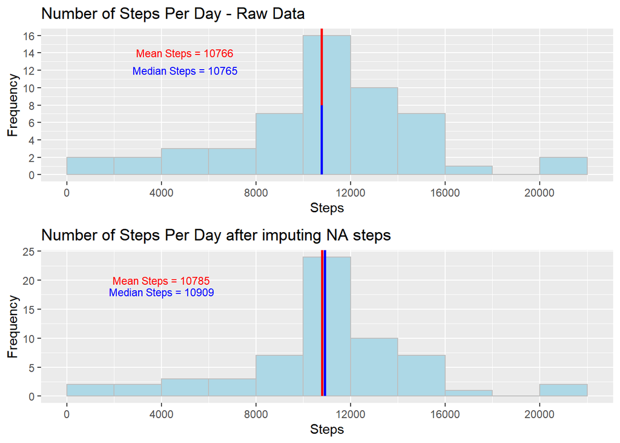

```r
gFull <- ggplot(stepsPerDayFull, aes(steps)) +
  geom_histogram(boundary = 0, binwidth = 2000, col = "grey", fill="lightblue") +
  ggtitle("Number of Steps Per Day after imputing NA steps") +
  xlab("Steps") + ylab("Frequency") +
  scale_x_continuous(breaks=seq(0,24000,4000)) +
  scale_y_continuous(breaks=seq(0,30,5)) +
  geom_segment(size=1, colour="red", aes(x=meanStepsbyDayFull, y=0, xend=meanStepsbyDayFull, yend=Inf)) +
  geom_segment(size=1, colour="blue", aes(x=medianStepsbyDayFull, y=0, xend=medianStepsbyDayFull, yend=Inf)) +
  annotate("text", x=4000, y=20, label=paste("Mean Steps =", as.character(round(meanStepsbyDayFull))), color="red", size = 3) +
  annotate("text", x=4000, y=18, label=paste("Median Steps =", as.character(round(medianStepsbyDayFull))), color="blue", size = 3)

library(gridExtra)
grid.arrange(g, gFull, nrow = 2)
```

```r
#save figure
dev.copy(png, file = "DailySteps_7.png", height = 600, width = 600)
```

```r
dev.off()
```

## Item8: Panel plot comparing the average number of steps taken per 5-minute interval across weekdays and weekends

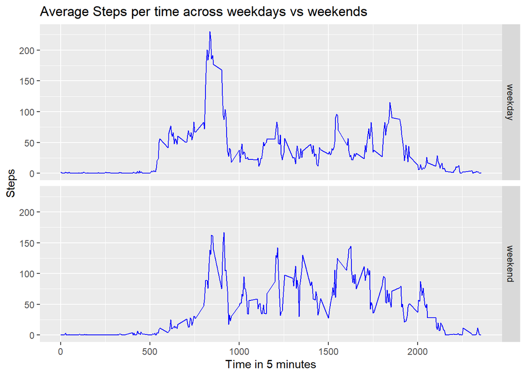

```r
activityFull$weekday <- "weekday"
activityFull$dayType <- weekdays(activityFull$date)
activityFull$weekday[which(activityFull$dayType == "Saturday" |
    activityFull$dayType == "Sunday")] <- "weekend"

stepsPerTimeWD <- aggregate(steps ~ interval+weekday, data=activityFull, FUN=mean, na.action=na.omit)

w <- ggplot(stepsPerTimeWD, aes(interval, steps))
w + geom_line(col="blue") +
  ggtitle("Average Steps per time across weekdays vs weekends") +
  xlab("Time in 5 minutes") + ylab("Steps") +
  facet_grid( weekday~.) +
  scale_x_continuous(breaks=seq(0,2500,500)) +
  scale_y_continuous(breaks=seq(0,300,50))
```

```r
#save figure
dev.copy(png, file = "DailySteps_8.png", height = 600, width = 600)
```

```r
dev.off()
```